# day-11-12

# Part 1:

```r
data("airquality")
str(airquality)
```

```
'data.frame':   153 obs. of  6 variables:
 $ Ozone  : int  41 36 12 18 NA 28 23 19 8 NA ...
 $ Solar.R: int  190 118 149 313 NA NA 299 99 19 194 ...
 $ Wind   : num  7.4 8 12.6 11.5 14.3 14.9 8.6 13.8 20.1 8.6 ...
 $ Temp   : int  67 72 74 62 56 66 65 59 61 69 ...
 $ Month  : int  5 5 5 5 5 5 5 5 5 5 ...
 $ Day    : int  1 2 3 4 5 6 7 8 9 10 ...
```

```r
summary(airquality)
```

```
     Ozone           Solar.R           Wind             Temp
 Min.   :  1.00   Min.   :  7.0   Min.   : 1.700   Min.   :56.00
 1st Qu.: 18.00   1st Qu.:115.8   1st Qu.: 7.400   1st Qu.:72.00
 Median : 31.50   Median :205.0   Median : 9.700   Median :79.00
 Mean   : 42.13   Mean   :185.9   Mean   : 9.958   Mean   :77.88
 3rd Qu.: 63.25   3rd Qu.:258.8   3rd Qu.:11.500   3rd Qu.:85.00
 Max.   :168.00   Max.   :334.0   Max.   :20.700   Max.   :97.00
 NA's   :37       NA's   :7
     Month            Day
 Min.   :5.000   Min.   : 1.0
 1st Qu.:6.000   1st Qu.: 8.0
 Median :7.000   Median :16.0
 Mean   :6.993   Mean   :15.8
 3rd Qu.:8.000   3rd Qu.:23.0
 Max.   :9.000   Max.   :31.0
```

## This data-set represents air quality and the variables that affect it, including Ozone, Solar Radiation, Wind, Temperature.

```r
shapiro.test(airquality$Ozone)
```

```
    Shapiro-Wilk normality test

data:  airquality$Ozone
W = 0.87867, p-value = 2.79e-08
```

```r
shapiro.test(airquality$Solar.R)
```

```
    Shapiro-Wilk normality test

data:  airquality$Solar.R
W = 0.94183, p-value = 9.492e-06
```

```r
shapiro.test(airquality$Wind)
```

```
    Shapiro-Wilk normality test

data:  airquality$Wind
W = 0.98575, p-value = 0.1178
```

```r
shapiro.test(airquality$Temp)
```

```
    Shapiro-Wilk normality test

data:  airquality$Temp
W = 0.97617, p-value = 0.009319
```

## The Shapiro-Wilk normality test is used to access if a dataset comes from a normal distribution. The null hypothesis of this test was whether the data follows a normal distribution and the alternative hypothesis was the data does not follow a normal distribution.

## Interpretting the p-value:

### Ozone: reject the null, use alternative hypothesis because data does not follow a normal distribution

### Solar radiation: reject the null, use alternative hypothesis because data does not follow a normal distribution

### Wind: fail to reject the null, use the null hypothesis because data does follow a normal distribution

### Temperature: reject the null, use the alternative hypothesis because data does not follow a normal distribution

# Part 2:

```r
library(dplyr)
airquality2 <- airquality |>
  mutate(Season = case_when(Month %in% c(11, 12, 1) ~ "Winter", Month %in% c(2, 3, 4) ~ "Spring", Month %in% c(5, 6, 7) ~ "Summer", Month %in% c(8, 9, 10) ~ "Fall"))
```

```r
table(airquality2$Season)
```

```
  Fall Summer
    61     92
```

## There 61 observations for the season of Fall and 92 observations from the Summer season.

# Part 3:

```r
library(recipes)
rec <- airquality2 |>
  recipe(~ Temp + Solar.R + Wind + Season) |>
  step_normalize(all_numeric_predictors()) |>
  step_dummy(all_nominal_predictors())
```

```r
rec2 <- rec |>
  step_impute_mean(all_numeric_predictors())
rec_prep <- prep(rec, training = airquality2)
processed_data <- bake(rec_prep, new_data = airquality2)
```

## Why is it necessary to both prep() and bake() the recipe?

### The prep function is necessary to ensure that the preprocessing steps are based on the data so the transformations are fitted correctly. The bake function makes sure the transformations are applied consistently to all the data.

# Part 4:

```r
model <- lm(Ozone ~ ., data = airquality)
summary(model)
```

```
Call:
lm(formula = Ozone ~ ., data = airquality)

Residuals:
    Min      1Q  Median      3Q     Max
-37.014 -12.284  -3.302   8.454  95.348

Coefficients:
             Estimate Std. Error t value Pr(>|t|)
(Intercept) -64.11632   23.48249  -2.730  0.00742 **
Solar.R       0.05027    0.02342   2.147  0.03411 *
Wind         -3.31844    0.64451  -5.149 1.23e-06 ***
Temp          1.89579    0.27389   6.922 3.66e-10 ***
Month        -3.03996    1.51346  -2.009  0.04714 *
Day           0.27388    0.22967   1.192  0.23576
---
Signif. codes:  0 '***' 0.001 '**' 0.01 '*' 0.05 '.' 0.1 ' ' 1

Residual standard error: 20.86 on 105 degrees of freedom
  (42 observations deleted due to missingness)
Multiple R-squared:  0.6249,    Adjusted R-squared:  0.6071
F-statistic: 34.99 on 5 and 105 DF,  p-value: < 2.2e-16
```

## The R-squared value explains about 62.5% of the variation in Ozone levels. The p-value shows the model is statistically significant. In terms of the coefficients, Temperature and wind have the strongest effects while day of the month is not a significant factor.

# Part 5:

```r
library(broom)
library(ggplot2)
library(ggpubr)
library(dplyr)
```

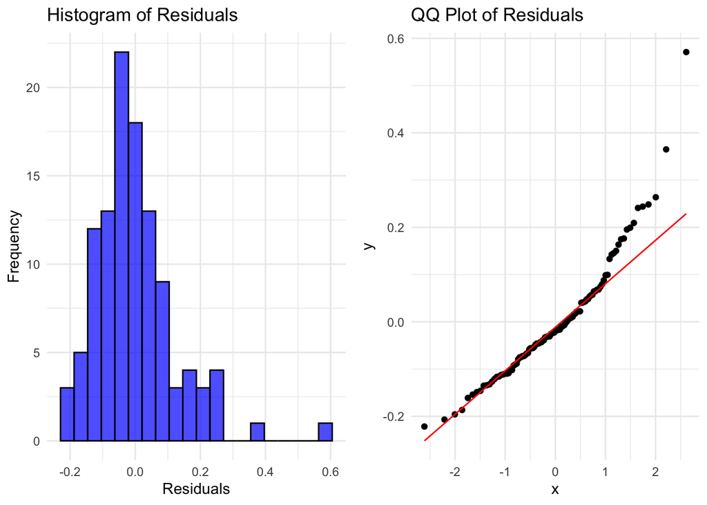

```r
airquality_clean <- na.omit(airquality)


normalize <- function(x) (x - min(x)) / (max(x) - min(x))

airquality_norm <- airquality_clean %>%
  mutate(across(c(Ozone, Solar.R, Wind, Temp), normalize))

model <- lm(Ozone ~ Solar.R + Wind + Temp + Month + Day, data = airquality_norm)


augmented_data <- augment(model, data = airquality_norm)

hist_resid <- ggplot(augmented_data, aes(.resid)) +
  geom_histogram(bins = 20, fill = "blue", color = "black", alpha = 0.7) +
  theme_minimal() +
  ggtitle("Histogram of Residuals") +
  xlab("Residuals") +
  ylab("Frequency")


qq_resid <- ggplot(augmented_data, aes(sample = .resid)) +
  stat_qq() +
  stat_qq_line(color = "red") +
  theme_minimal() +
  ggtitle("QQ Plot of Residuals")


ggarrange(hist_resid, qq_resid, ncol = 2, nrow = 1)
```

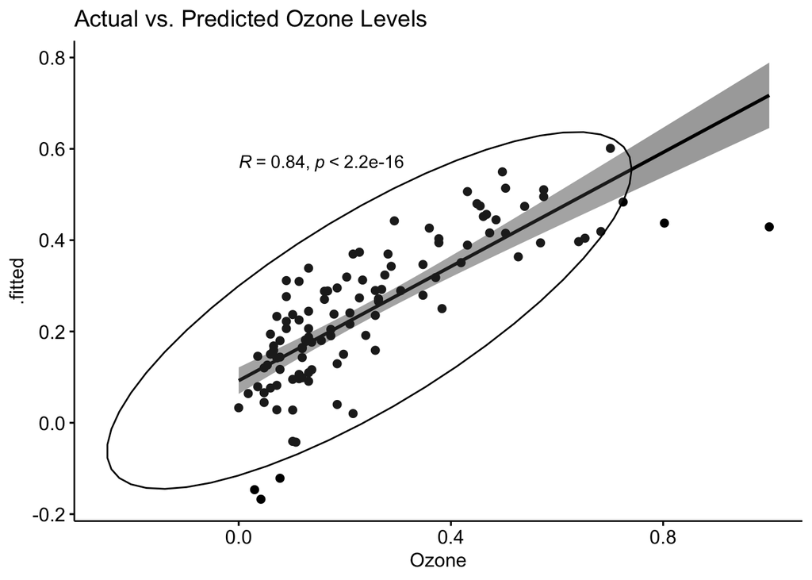

```r
scatter_plot <- ggscatter(augmented_data, x = "Ozone", y = ".fitted",
                          add = "reg.line", conf.int = TRUE,
                          cor.coef = TRUE, cor.method = "spearman",
                          ellipse = TRUE) +
  ggtitle("Actual vs. Predicted Ozone Levels")

print(scatter_plot)
```

## I think this is a strong enough model because the R-squared accounted for about 62.5% of the variation in ozone levels and the p-value was statistically significant.